# Projet Python

## 1) Chargement des packages

```python
import sklearn as sl
import pandas as pd
import numpy as np
import scipy as sp
from sklearn.ensemble import RandomForestClassifier
from sklearn.model_selection import train_test_split
from sklearn.linear_model import LogisticRegression
from sklearn.grid_search import GridSearchCV
import matplotlib.pyplot as plt
from sklearn.ensemble import GradientBoostingClassifier
from sklearn.metrics import roc_curve, auc
import xgboost as xgb
import pylab as P
```

## 2) Importation des données

```python
path = "/Users/celinekociemba/Desktop/Donnees/"
train = pd.DataFrame.from_csv(path + "donnees_projet_train.csv")
valid = pd.DataFrame.from_csv(path + "donnees_projet_valid.csv" )
```

#### *Dimension*

```python
train.shape
```

```
(51381, 128)
```

Notre jeu est constitué de 51381 lignes et 128 colonnes.

#### *Type de variable*

```python
train.dtypes.head() # on affiche uniquement le type des premières variables
```

```
Id                  int64
Product_Info_1      int64
Product_Info_2     object
Product_Info_3      int64
Product_Info_4    float64
dtype: object
```

Nous distinguons 3 types de variables dans notre jeu :

- integer,float (variables quantitatives)
- objet (variable qualitative)

Par ailleurs, nous observons qu'une seule variable qualitative : "Product_Info_2"

## 3) Création des Objets

Dans cette partie, nous allons creer des objets qui vont permettre de faciliter et d'automatiser l'exploitation des données.

D'une part, nous allons isoler la variable cible "target" à expliquer des autres variables (explicatives) :

```python
# variable à expliquer y
y = train["target"]

# variables explicatives X
X = train.drop(["target"], 1)
```

D'autre part, parmi les variables explicatives, nous allons différencier celles qui sont quantitatives et celles qui sont qualitatives.

```python
# variables explicatives qualitatives
ind_quali = np.where(X.dtypes == 'object')
var_quali = X.iloc[:,ind_quali[0]]

# variables explicatives quantitatives
ind_float = np.where(X.dtypes == 'float64')
ind_int = np.where(X.dtypes == 'int64')
ind_quanti = np.array(list(set(ind_float[0]) | set(ind_int[0])),int)
var_quanti = X.iloc[:,ind_quanti]
```

L'objectif principal de cette démarche est de pouvoir creer un object de type matrice pour les variables quantitatives afin de pouvoir les manipuler plus facilement. Il seras ensuite possible de remplacer automatiquement et rapidement les NAs par la médiane. Cette étape est indispensable pour pouvoir utiliser toutes les fonctions python sans pertuber la distribution des données.

```python
## creation matrice pour les variables quantitatives
mat = np.array(var_quanti)
labels_quanti = var_quanti.columns
```

## 4) Description des variables

### Variable à expliquer : y

```python
y.describe()
```

```
count    51381.000000
mean         0.328487
std          0.469668
min          0.000000
25%          0.000000
50%          0.000000
75%          1.000000
max          1.000000
Name: target, dtype: float64
```

D'apres l'analyse de cette sortie, la réalisation (modalité à 1) de la variable cible y est observée dans environ 32,8487% de notre population. Il n'y a pas de valeurs manquantes.

```python
name = ['0', '1']
liste_y = list(y)
y_count = [liste_y.count(0),liste_y.count(1)]
y_count
```

```
[34503, 16878]
```

```python
y = y.astype('uint8')
y.dtypes
```

```
dtype('uint8')
```

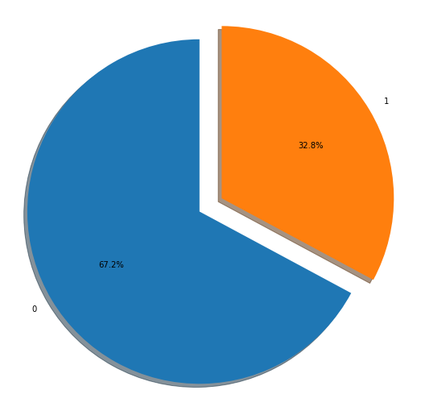

```python
explode=(0.15,0)
fig = plt.figure(1, figsize=(9, 9))
plt.pie(y_count, explode=explode, labels=name, autopct='%1.1f%%', startangle=90, shadow=True)
plt.axis('equal')
plt.show()
```

Nous comptons donc 16878 réalisation de la variable à expliquer sur 51381 (soit 32,8%)

### Variables explicatives : X

#### *Variable Qualitative*

```python
var_quali.describe()
```

|  | Product_Info_2 |
| --- | --- |
| count | 51381 |
| unique | 19 |
| top | D3 |
| freq | 12470 |

La seule variable explicative quatitative contient 19 valeurs uniques. La classe la plus fréquente est "D3". En effet, elle contient 12470 des observations soit 24,269671% de la population.

#### *Variables Quantitatives*

```python
var_quanti.describe()
```

|  | Id | Product_Info_1 | Product_Info_3 | Product_Info_4 | Product_Info_5 | Product_Info_6 | Product_Info_7 | Ins_Age | Ht | Wt | ... | Medical_Keyword_39 | Medical_Keyword_40 | Medical_Keyword_41 | Medical_Keyword_42 | Medical_Keyword_43 | Medical_Keyword_44 | Medical_Keyword_45 | Medical_Keyword_46 | Medical_Keyword_47 | Medical_Keyword_48 |
| --- | --- | --- | --- | --- | --- | --- | --- | --- | --- | --- | --- | --- | --- | --- | --- | --- | --- | --- | --- | --- | --- |
| count | 51381.000000 | 51381.000000 | 51381.000000 | 51381.000000 | 51381.000000 | 51381.000000 | 51381.000000 | 51381.000000 | 51381.000000 | 51381.000000 | ... | 51381.000000 | 51381.000000 | 51381.000000 | 51381.000000 | 51381.000000 | 51381.000000 | 51381.000000 | 51381.000000 | 51381.000000 | 51381.000000 |
| mean | 39528.812635 | 1.026002 | 24.416049 | 0.328934 | 2.006948 | 2.672097 | 1.042934 | 0.405657 | 0.707231 | 0.292492 | ... | 0.013682 | 0.056772 | 0.010043 | 0.045678 | 0.010841 | 0.007824 | 0.013721 | 0.008700 | 0.019910 | 0.054456 |
| std | 22800.993433 | 0.159142 | 5.068379 | 0.282703 | 0.083066 | 0.740471 | 0.289806 | 0.197115 | 0.074177 | 0.088967 | ... | 0.116169 | 0.231409 | 0.099709 | 0.208789 | 0.103553 | 0.088107 | 0.116332 | 0.092867 | 0.139693 | 0.226917 |
| min | 2.000000 | 1.000000 | 1.000000 | 0.000000 | 2.000000 | 1.000000 | 1.000000 | 0.000000 | 0.000000 | 0.000000 | ... | 0.000000 | 0.000000 | 0.000000 | 0.000000 | 0.000000 | 0.000000 | 0.000000 | 0.000000 | 0.000000 | 0.000000 |
| 25% | 19783.000000 | 1.000000 | 26.000000 | 0.076923 | 2.000000 | 3.000000 | 1.000000 | 0.238806 | 0.654545 | 0.225941 | ... | 0.000000 | 0.000000 | 0.000000 | 0.000000 | 0.000000 | 0.000000 | 0.000000 | 0.000000 | 0.000000 | 0.000000 |
| 50% | 39583.000000 | 1.000000 | 26.000000 | 0.230769 | 2.000000 | 3.000000 | 1.000000 | 0.402985 | 0.709091 | 0.288703 | ... | 0.000000 | 0.000000 | 0.000000 | 0.000000 | 0.000000 | 0.000000 | 0.000000 | 0.000000 | 0.000000 | 0.000000 |
| 75% | 59167.000000 | 1.000000 | 26.000000 | 0.487179 | 2.000000 | 3.000000 | 1.000000 | 0.567164 | 0.763636 | 0.345188 | ... | 0.000000 | 0.000000 | 0.000000 | 0.000000 | 0.000000 | 0.000000 | 0.000000 | 0.000000 | 0.000000 | 0.000000 |
| max | 79145.000000 | 2.000000 | 38.000000 | 1.000000 | 3.000000 | 3.000000 | 3.000000 | 0.970149 | 1.000000 | 1.000000 | ... | 1.000000 | 1.000000 | 1.000000 | 1.000000 | 1.000000 | 1.000000 | 1.000000 | 1.000000 | 1.000000 | 1.000000 |

8 rows × 126 columns

## 5) Nettoyage des données

#### *Traitement des NAs*

A partir de la matrice crée, nous remplacons les valeurs manquantes NAs par la médiane.

```python
# traitement des NAs : remplacer par la médiane, on utilise matrice pour plus de souplesse + performance

for j in range(mat.shape[1]):
    if any(np.isnan(mat[:,j])) :
        mediane = np.median(mat[~np.isnan(mat[:,j]),j])
        mat[np.isnan(mat[:,j]),j] = mediane

var_quanti = pd.DataFrame(mat,columns = labels_quanti) # on ajuste le data_frame
```

#### *Mise en place des indicatrices*

```python
#binairisation des variable qualitatives

# Table des indicatrices
indicatrices = pd.get_dummies(var_quali[["Product_Info_2"]],dummy_na=True)
indicatrices.index = indicatrices.index - 1
X = pd.concat([var_quanti,indicatrices], axis=1)

# Vérification
X.columns
```

```
Index(['Id', 'Product_Info_1', 'Product_Info_3', 'Product_Info_4',
       'Product_Info_5', 'Product_Info_6', 'Product_Info_7', 'Ins_Age', 'Ht',
       'Wt',
       ...
       'Product_Info_2_C1', 'Product_Info_2_C2', 'Product_Info_2_C3',
       'Product_Info_2_C4', 'Product_Info_2_D1', 'Product_Info_2_D2',
       'Product_Info_2_D3', 'Product_Info_2_D4', 'Product_Info_2_E1',
       'Product_Info_2_nan'],
      dtype='object', length=146)
```

## 6) Création des echantillons test + apprentissage

echantillon test : 20%

echantillon d'apprentissage : 80%

```python
X_train, X_test, y_train, y_test = train_test_split(X, y, test_size=0.20)
```

## 7) Régression logistique

$ log \biggl( \frac{p(X)}{1-p(X)} \biggr) = \beta_0 + \beta_1 X $ avec $p(X)$ la probabilité que x soit de la classe 1

#### *Détermination des paramêtres*

```python
 # grille de valeurs
param=[{"C":[3,4,4.1,4.2,4.3,4.4,4.5,5]}]
logit = GridSearchCV(LogisticRegression(penalty="l1"),
    param,cv=5,n_jobs=-1)
titan_logit=logit.fit(X_train, y_train)
 # paramètre optimal
titan_logit.best_params_["C"]
```

```
4.5
```

Le paramètre "penalty" correspond au type de pénalisation du modèle : lasso (norme 1 : l1) et ridge (norme 2 : l2) . Ici, aprés plusieurs essais, nous opterons pour une penalisation lasso.

Par ailleurs,n_jobs correspond au nombre de coeurs CPU mobilisés lors de la parallélisation. La valeur est fixée à -1. Tous les coeurs sont utilisés.

Enfin C correspond au paramètre de force de regularisation. La valeure optimale trouvée est de 4.5.

#### *Modélisation*

```python
logit = LogisticRegression(C=4.5,penalty="l1")
titan_logit=logit.fit(X_train, y_train)
```

Nous pouvons alors estimer les coefficients du modèle :

```python
# Coefficients
coef = titan_logit.coef_
coef[0,0:10] # on affiche que les 10 premiers
```

```
array([  2.60696032e-07,  -9.31551340e-01,  -1.04934335e-02,
         6.07663189e-01,  -5.35508760e-01,  -3.87942523e-02,
         1.39028549e-01,  -1.08728888e+00,   2.47801871e+00,
        -5.19063729e+00])
```

On trouve également le taux d'exactitude moyen :

```python
# Erreur
titan_logit.score(X_test, y_test)
```

```
0.82660309428821643
```

#### *Prédiction*

```python
y_score = titan_logit.predict(X_test)
scores = titan_logit.predict_proba(X_test)
```

#### *Courbe ROC*

A partir des prédictions précédentes, nous mettons en place la courbe roc afin d'apprécier la classification des observations.

On calcule également l'indicateur AUC qui vaut 0.90.

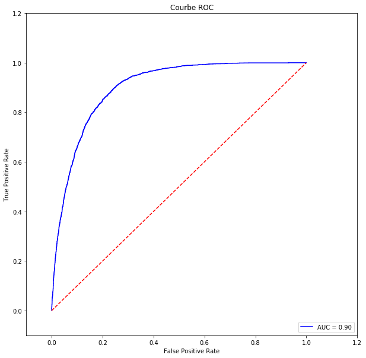

```python
fpr, tpr, thresholds = roc_curve(y_test, scores[:,1])
roc_auc = auc(fpr, tpr)

fig = plt.figure(1, figsize=(10, 10))
plt.title('Courbe ROC')
plt.plot(fpr, tpr, 'b',label='AUC = %0.2f'% roc_auc)
plt.legend(loc='lower right')
plt.plot([0,1],[0,1],'r--')
plt.xlim([-0.1,1.2])
plt.ylim([-0.1,1.2])
plt.ylabel('True Positive Rate')
plt.xlabel('False Positive Rate')
plt.show()
```

#### *Validation*

Notre modèle semble performant.

Cependant, nous devons maintenant le valider. Pour cela, nous allons utiliser tout le jeu de données (test + apprentissage) pour la modélisation en ajustant avec les paramêtres trouvés precedemment.

Ainsi, le modèle sera plus robuste.

```python
final_logit=logit.fit(X, y)
```

```python
valid.shape
```

```
(8000, 127)
```

Notre échantillon de validation contient 8000 lignes et 127 colonnes. En effet, il ne contient pas la variable cible "target" car l'objectif est de prédire ses valeurs. Au préalable, il faut traiter l'échantillon de validation (médiane, indicatrices ...) :

```python
# traitement de l'échantillon de validation
var_quali2 = valid.iloc[:,ind_quali[0]]
var_quanti2 = valid.iloc[:,ind_quanti]
mat2 = np.array(var_quanti2)
labels_quanti2 = var_quanti2.columns
# mediane
for j in range(mat2.shape[1]):
    if any(np.isnan(mat2[:,j])) :
        mediane = np.median(mat2[~np.isnan(mat2[:,j]),j])
        mat2[np.isnan(mat2[:,j]),j] = mediane
var_quanti2 = pd.DataFrame(mat2,columns = labels_quanti2) # on ajuste le data_frame
# Table des indicatrices
indicatrices2 = pd.get_dummies(var_quali2[["Product_Info_2"]],dummy_na=True)
indicatrices2.index = indicatrices2.index - 1
X_valid = pd.concat([var_quanti2,indicatrices2], axis=1)
```

Nous pouvons enfin prédire nos valeurs ainsi que les probablités de réalisation liées à cette valeur sur notre échantillon de validation :

```python
y_score_valid = final_logit.predict(X_valid)
y_score_valid
```

```
array([0, 0, 1, ..., 0, 0, 0], dtype=uint8)
```

```python
scores_valid = final_logit.predict_proba(X_valid)
scores_valid
```

```
array([[ 0.53370342,  0.46629658],
       [ 0.56740566,  0.43259434],
       [ 0.44097326,  0.55902674],
       ...,
       [ 0.84325272,  0.15674728],
       [ 0.98926047,  0.01073953],
       [ 0.99393485,  0.00606515]])
```

On peut ensuite toujours ajouter l'échantillon de validation lors de la modélisation pour encore plus de robustesse.

## 8) Forêts aléatoires

#### *Détermination des paramêtres*

```python
param=[{"max_features":list(range(37,41,1))}]
digit_rf= GridSearchCV(RandomForestClassifier(
   n_estimators=400),param,cv=5,n_jobs=-1)
digit_rf=digit_rf.fit(X_train, y_train)
# paramètre optimal
digit_rf.best_params_
```

```
{'max_features': 39}
```

"n_estimator" correspond au nombre d'arbres sur lequel nous voulons apprendre.

"max_feature" correspond au nombre de colonnes prises en considération à chaque noeud.

le paramètre "max_depth" permet de regler la profondeur de l'arbre.

Le "max_feature" optimal est de 39.

A pres plusieurs essais, on prend n_estimator = 400.

#### *Modélisation*

Nous utilisons les paramètres trouvés précedemment dans notre Random Forest. Nous activons également le paramêtre bootstrat.

```python
forest = RandomForestClassifier(n_estimators=400,
   criterion='gini', max_depth=None,
   min_samples_split=2, min_samples_leaf=1,
max_features=39, max_leaf_nodes=None,
   bootstrap=True, oob_score=True)
# apprentissage
forest = forest.fit(X_train,y_train)
print(1-forest.oob_score_)
```

```
0.157819190346
```

L'erreur de prédiction moyenne (OOB) sur chaque échantillon d'apprentissage est environ égale à 0.157819. L'erreur Out-of-bag est une méthode de mesure de l'erreur de prédiction des forêts aléatoires.

#### *Prédiction*

```python
# prévision
y_score = forest.predict(X_test)
y_score
```

```
array([1, 0, 0, ..., 0, 0, 1], dtype=uint8)
```

```python
# Probabilités d'appartenance
scores = forest.predict_proba(X_test)
scores
```

```
array([[ 0.4925,  0.5075],
       [ 0.9075,  0.0925],
       [ 0.5675,  0.4325],
       ...,
       [ 0.9775,  0.0225],
       [ 0.595 ,  0.405 ],
       [ 0.2175,  0.7825]])
```

taux d'exactitude moyen :

```python
# erreur de prévision sur le test
forest.score(X_test,y_test)
```

```
0.83973922350880603
```

#### *Courbe ROC*

A partir des prédictions précédentes, nous mettons en place la courbe roc afin d'apprécier la classification des observations.

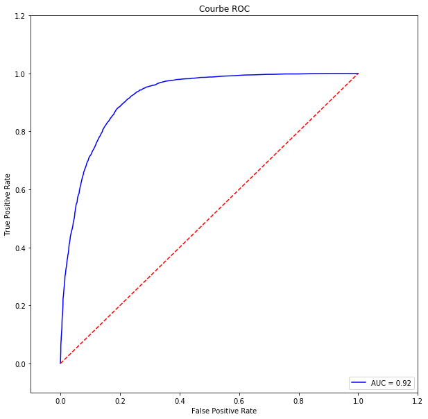

```python
fpr, tpr, thresholds = roc_curve(y_test, scores[:,1])
roc_auc = auc(fpr, tpr)

fig = plt.figure(1, figsize=(10, 10))
plt.title('Courbe ROC')
plt.plot(fpr, tpr, 'b',label='AUC = %0.2f'% roc_auc)
plt.legend(loc='lower right')
plt.plot([0,1],[0,1],'r--')
plt.xlim([-0.1,1.2])
plt.ylim([-0.1,1.2])
plt.ylabel('True Positive Rate')
plt.xlabel('False Positive Rate')
plt.show()
```

#### *Matrice de confusion*

```
col_0      0     1
target
0       5977   915
1        732  2653
```

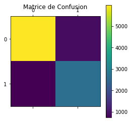

```python
# matrice de confusion

table=pd.crosstab(y_test,y_score)
print(table)

plt.matshow(table)
plt.title("Matrice de Confusion")
plt.colorbar()
plt.show()
```

#### *Validation*

On apprend sur l'ensemble de notre jeu de données :

```python
final_forest=forest.fit(X, y)
```

Nous pouvons enfin prédire nos valeurs ainsi que les probablité de réalisation liées à cette valeur sur notre échantillon de validation :

```python
y_score_valid = final_forest.predict(X_valid)
y_score_valid
```

```
array([0, 0, 0, ..., 0, 0, 0], dtype=uint8)
```

```python
scores_valid = final_forest.predict_proba(X_valid)
scores_valid
```

```
array([[ 0.5275,  0.4725],
       [ 0.58  ,  0.42  ],
       [ 0.5925,  0.4075],
       ...,
       [ 0.83  ,  0.17  ],
       [ 0.91  ,  0.09  ],
       [ 0.94  ,  0.06  ]])
```

## 9) XgBoost

#### *Détermination des paramêtres*

Afin d'optimiser la modélisation, nous faisons varier le paramêtre "max_depth" (profondeur de l'arbre) et "min_child_weight"(le nombre d'élément minimum dans chaque feuille)

```python
cv_params = {'max_depth': [7,8,9],'min_child_weight': [1,3,5]}
ind_params = {'learning_rate': 0.1, 'n_estimators': 200}
```

```python
optimized_GBM = GridSearchCV(xgb.XGBClassifier(**ind_params),
                            cv_params,
                             scoring = 'accuracy', cv = 5, n_jobs = -1)
```

```python
optimized_GBM.fit(X_train, y_train)
optimized_GBM.grid_scores_
```

```
[mean: 0.84422, std: 0.00375, params: {'max_depth': 7, 'min_child_weight': 1},
 mean: 0.84410, std: 0.00383, params: {'max_depth': 7, 'min_child_weight': 3},
 mean: 0.84551, std: 0.00416, params: {'max_depth': 7, 'min_child_weight': 5},
 mean: 0.84571, std: 0.00337, params: {'max_depth': 8, 'min_child_weight': 1},
 mean: 0.84466, std: 0.00401, params: {'max_depth': 8, 'min_child_weight': 3},
 mean: 0.84466, std: 0.00368, params: {'max_depth': 8, 'min_child_weight': 5},
 mean: 0.84357, std: 0.00393, params: {'max_depth': 9, 'min_child_weight': 1},
 mean: 0.84491, std: 0.00167, params: {'max_depth': 9, 'min_child_weight': 3},
 mean: 0.84508, std: 0.00288, params: {'max_depth': 9, 'min_child_weight': 5}]
```

Apres avoir testé plusieur valeur pour le parmêtre "learning_rate", la vitesse d'apprentissage sélectionnée est 0.1.

On prend "max_depth" = 8 et "min_child_weight" = 1.

#### *Modélisation*

```python
xgboost = xgb.XGBClassifier(colsample_bytree=1,
                            gamma=0, learning_rate=0.1,max_depth=8,
                            min_child_weight=1, n_estimators=500, nthread=-1,
                            reg_alpha=0, reg_lambda=1,
                            subsample=1)
xgboost.fit(X_train, y_train)
```

```
XGBClassifier(base_score=0.5, colsample_bylevel=1, colsample_bytree=1,
       gamma=0, learning_rate=0.1, max_delta_step=0, max_depth=8,
       min_child_weight=1, missing=None, n_estimators=500, nthread=-1,
       objective='binary:logistic', reg_alpha=0, reg_lambda=1,
       scale_pos_weight=1, seed=0, silent=True, subsample=1)
```

"colsample_bytree" est le pourcentage de colonnes utilisées par noeud. (par défaut 1)

"gamma" est le gain minimum pour valider un split. (defaut:0)

learning_rate est la vitesse d'apprentissage.

max_depth est la profondeur maximum de l'arbre.

min_child_weight est le nombre d'élement minimum dans chaque feuille. (défaut:1)

n_estimators est le nombre d'arbres.

reg_alpha correspond à la régularisation L1.

reg_lambda correspond à la régularisation L2.

subsample (bootstrat) : selection, aléatoire de lignes.

#### *Prédiction*

```python
# prévision
y_score = xgboost.predict(X_test)
y_score
```

```
array([0, 0, 1, ..., 0, 1, 1], dtype=uint8)
```

```python
# Probabilités d'appartenance
scores = xgboost.predict_proba(X_test)
scores
```

```
array([[  9.28982735e-01,   7.10172951e-02],
       [  9.99978006e-01,   2.19901358e-05],
       [  4.93591964e-01,   5.06408036e-01],
       ...,
       [  9.99079764e-01,   9.20248334e-04],
       [  4.06142890e-01,   5.93857110e-01],
       [  9.85572338e-02,   9.01442766e-01]], dtype=float32)
```

```python
# erreur de prévision sur le test
xgboost.score(X_test,y_test)
```

```
0.84363140994453634
```

#### *Courbe ROC*

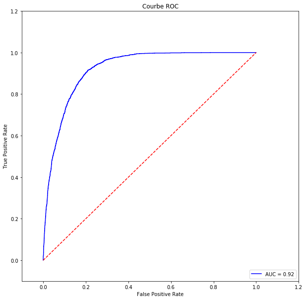

```python
fpr, tpr, thresholds = roc_curve(y_test, scores[:,1])
roc_auc = auc(fpr, tpr)

fig = plt.figure(1, figsize=(10, 10))
plt.title('Courbe ROC')
plt.plot(fpr, tpr, 'b',label='AUC = %0.2f'% roc_auc)
plt.legend(loc='lower right')
plt.plot([0,1],[0,1],'r--')
plt.xlim([-0.1,1.2])
plt.ylim([-0.1,1.2])
plt.ylabel('True Positive Rate')
plt.xlabel('False Positive Rate')
plt.show()
```

On trouve un AUC égale à 0.92.

#### *Validation*

On apprend sur l'ensemble de notre jeu de données :

```python
final_xgboost=xgboost.fit(X, y)
```

Nous pouvons enfin prédire nos valeurs ainsi que les probablité de réalisation liée à cette valeur sur notre echantillon de validation :

```python
y_score_valid = final_xgboost.predict(X_valid)
scores_valid = final_xgboost.predict_proba(X_valid)
```

#### *Poids des variables*

Afin de comprendre et de représenter l'impact des variables sur notre cible, on affiche l'importance (à partir du poids) des variables dans notre modélisation XgBoost.

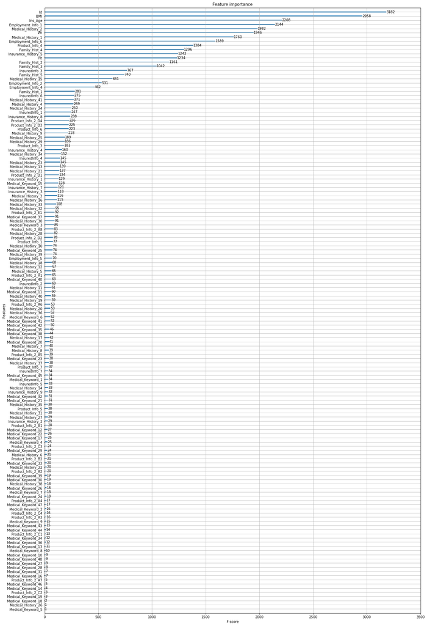

[figure not shown]

```python
ax = xgb.plot_importance(final_xgboost)
fig = ax.figure
fig.set_size_inches(20, 33)
plt.show()
```

## 10) Data visualisation

Il s'agit d'une variable quantitative.

### Représentation univariée

```python
X["BMI"].describe()
```

```
count    51381.000000
mean         0.469368
std          0.122167
min          0.000000
25%          0.385517
50%          0.451275
75%          0.532352
max          1.000000
Name: BMI, dtype: float64
```

La moyenne est égale à 0.46939.

75% de la population se trouvent entre 0 et 0.5323352.

On affiche ensuite la distribution de la variable BMI :

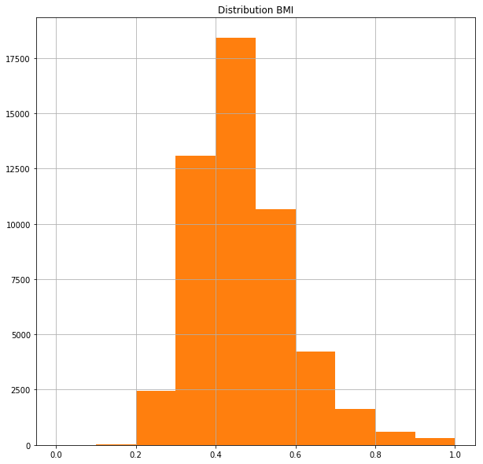

```python
fig = plt.figure(1, figsize=(10, 10))
X["BMI"].hist()
plt.title("Distribution BMI")
plt.show()
```

L'intervalle qui contient le plus grand nombre d'individus est entre 0.4 et 0.5.  
Ensuite, une importante proportion se situe également dans l'intervalle [0.3;0.4].

### Représentation bivariée

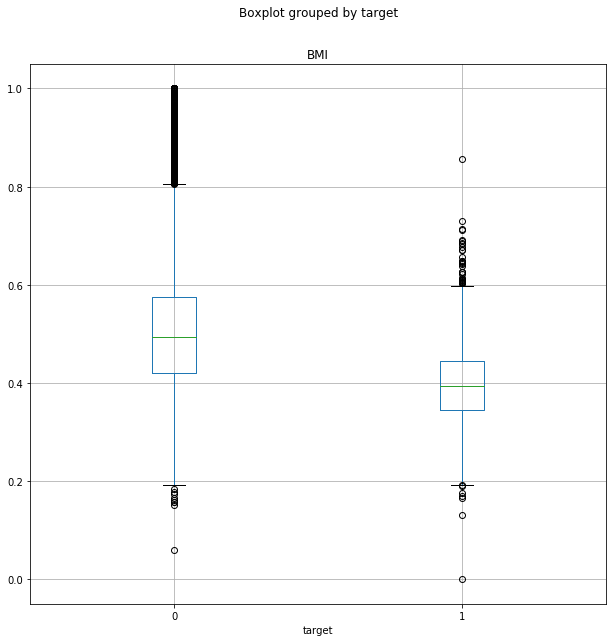

```python
y.index = y.index - 1
data = pd.concat([X,y], axis=1)
data.boxplot(column="BMI",by="target",figsize = (10,10))
plt.show()
```

IL apparait clairement que les individus de la classe 1 (réalisation de la variable cible) ont tendance a avoir une valeur de BMI beaucoup plus faible en comparaison à la classe 0. Cette observation nous réconforte dans notre étude : la variable BMI semble avoir un fort impact sur la variable "target".

On propose également une autre représentation. Pour cela, on crée 3 classes pour notre variable BMI :

Elle devient alors une variable qualitative, on va alors croiser la variable cible "target" avec la variable BMI à partir d'une représentation graphique nommée : mosaic.

```python
BMI = np.array(X["BMI"])
BMI_int = [" "] * len(BMI)


for i in range(len(BMI)):
    if (BMI[i] < 0.4) : BMI_int[i] = "<0.4"
    if (BMI[i] >= 0.4 and BMI[i] < 0.6 ) : BMI_int[i] = "[0.4,0.6]"
    if (BMI[i] >= 0.5 ) : BMI_int[i] = ">0.6"


BMI_int = pd.DataFrame(BMI_int)
BMI_int.describe()
BMI_int.columns = ['BMI2']
BMI_int["BMI2"].value_counts()

data2 = pd.concat([data,BMI_int], axis=1)
```

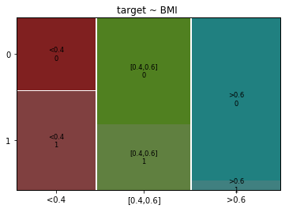

```python
# table de contingence
table=pd.crosstab(data2["BMI2"],data2["target"])
#print(table)
# Mosaics plots
from statsmodels.graphics.mosaicplot import mosaic
mosaic(data2,["BMI2","target"],title = "target ~ BMI ")

plt.show()
```

On constaste que les individus dont le BMI est supérieur à 0.4 ont tendance à se retrouver dans la classe 0. Et inversement. On peut penser que plus le BMI baisse plus la probabilité d'appartenance à la classe 1 augmente.